# Assignment 05 - FML

Chandima Attanayake

2024-11-03

# 1. Load the Data and Inspect

```r
options(repos = c(CRAN = "https://cloud.r-project.org/"))
install.packages("factoextra")
# Load necessary libraries
library(tidyverse)
# Load the dataset
wine_data <- read.csv("/Users/chandimaattanayake/Downloads/wine-clustering.csv")

# Inspect the data
head(wine_data)
```

```
##   Alcohol Malic_Acid  Ash Ash_Alcanity Magnesium Total_Phenols Flavanoids
## 1   14.23       1.71 2.43         15.6       127          2.80       3.06
## 2   13.20       1.78 2.14         11.2       100          2.65       2.76
## 3   13.16       2.36 2.67         18.6       101          2.80       3.24
## 4   14.37       1.95 2.50         16.8       113          3.85       3.49
## 5   13.24       2.59 2.87         21.0       118          2.80       2.69
## 6   14.20       1.76 2.45         15.2       112          3.27       3.39
##   Nonflavanoid_Phenols Proanthocyanins Color_Intensity  Hue OD280 Proline
## 1                 0.28            2.29            5.64 1.04  3.92    1065
## 2                 0.26            1.28            4.38 1.05  3.40    1050
## 3                 0.30            2.81            5.68 1.03  3.17    1185
## 4                 0.24            2.18            7.80 0.86  3.45    1480
## 5                 0.39            1.82            4.32 1.04  2.93     735
## 6                 0.34            1.97            6.75 1.05  2.85    1450
```

```r
summary(wine_data)
```

```
##     Alcohol        Malic_Acid         Ash         Ash_Alcanity
##  Min.   :11.03   Min.   :0.740   Min.   :1.360   Min.   :10.60
##  1st Qu.:12.36   1st Qu.:1.603   1st Qu.:2.210   1st Qu.:17.20
##  Median :13.05   Median :1.865   Median :2.360   Median :19.50
##  Mean   :13.00   Mean   :2.336   Mean   :2.367   Mean   :19.49
##  3rd Qu.:13.68   3rd Qu.:3.083   3rd Qu.:2.558   3rd Qu.:21.50
##  Max.   :14.83   Max.   :5.800   Max.   :3.230   Max.   :30.00
##    Magnesium      Total_Phenols     Flavanoids    Nonflavanoid_Phenols
##  Min.   : 70.00   Min.   :0.980   Min.   :0.340   Min.   :0.1300
##  1st Qu.: 88.00   1st Qu.:1.742   1st Qu.:1.205   1st Qu.:0.2700
##  Median : 98.00   Median :2.355   Median :2.135   Median :0.3400
##  Mean   : 99.74   Mean   :2.295   Mean   :2.029   Mean   :0.3619
##  3rd Qu.:107.00   3rd Qu.:2.800   3rd Qu.:2.875   3rd Qu.:0.4375
##  Max.   :162.00   Max.   :3.880   Max.   :5.080   Max.   :0.6600
##  Proanthocyanins Color_Intensity       Hue             OD280
##  Min.   :0.410   Min.   : 1.280   Min.   :0.4800   Min.   :1.270
##  1st Qu.:1.250   1st Qu.: 3.220   1st Qu.:0.7825   1st Qu.:1.938
##  Median :1.555   Median : 4.690   Median :0.9650   Median :2.780
##  Mean   :1.591   Mean   : 5.058   Mean   :0.9574   Mean   :2.612
##  3rd Qu.:1.950   3rd Qu.: 6.200   3rd Qu.:1.1200   3rd Qu.:3.170
##  Max.   :3.580   Max.   :13.000   Max.   :1.7100   Max.   :4.000
##     Proline
##  Min.   : 278.0
##  1st Qu.: 500.5
##  Median : 673.5
##  Mean   : 746.9
##  3rd Qu.: 985.0
##  Max.   :1680.0
```

*Q1 K-Means Clustering*

Q1-A) Normalization and Number of Clusters (k)

Normalization is crucial for K-Means because the attributes vary in scale, so normalizing helps ensure equal weighting. The choice of k influences the cluster formation, and we typically use methods like the elbow method or silhouette score to find an optimal k.

Q1-B) Applying K-Means

Normalize the data: Use scale() to normalize. Determine optimal k: Use the elbow method and silhouette method to find the best k. Cluster the data: Use kmeans() with the chosen k, then visualize and analyze clusters.

```r
install.packages("factoextra")
library(factoextra)
```

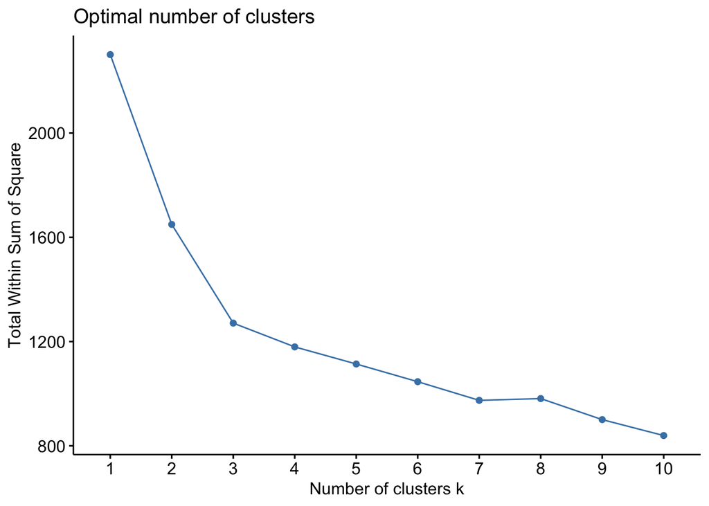

```r
library(cluster)

# Normalize data
wine_norm <- scale(wine_data)

# Determine optimal k using WSS and Silhouette methods
fviz_nbclust(wine_norm, kmeans, method = "wss")
```

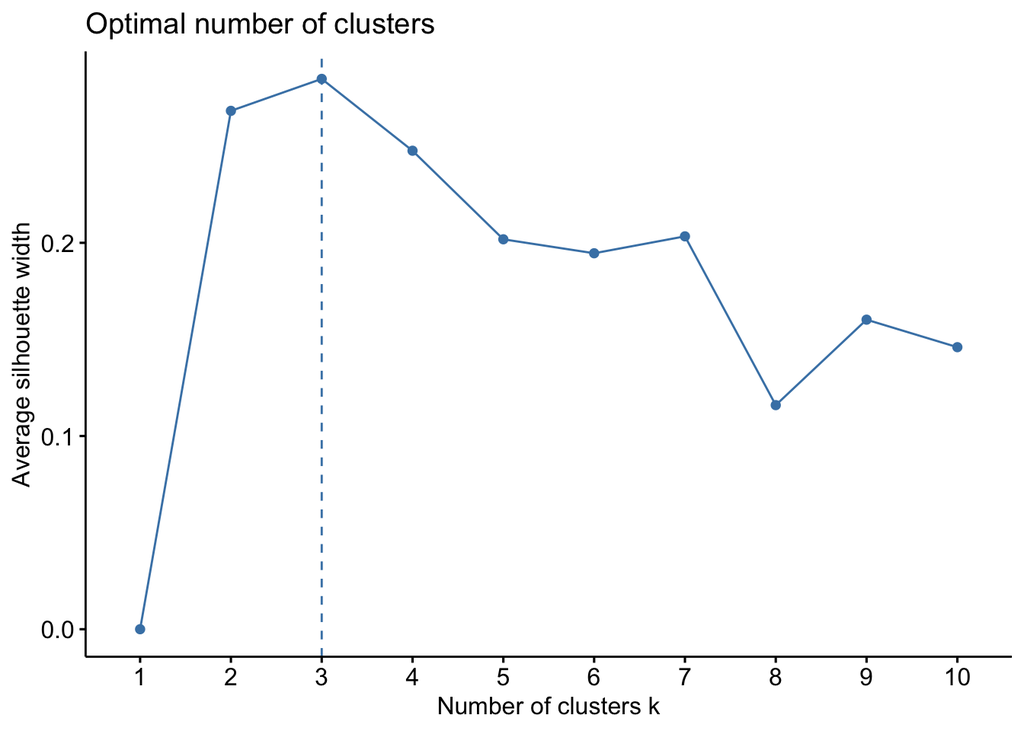

```r
fviz_nbclust(wine_norm, kmeans, method = "silhouette")
```

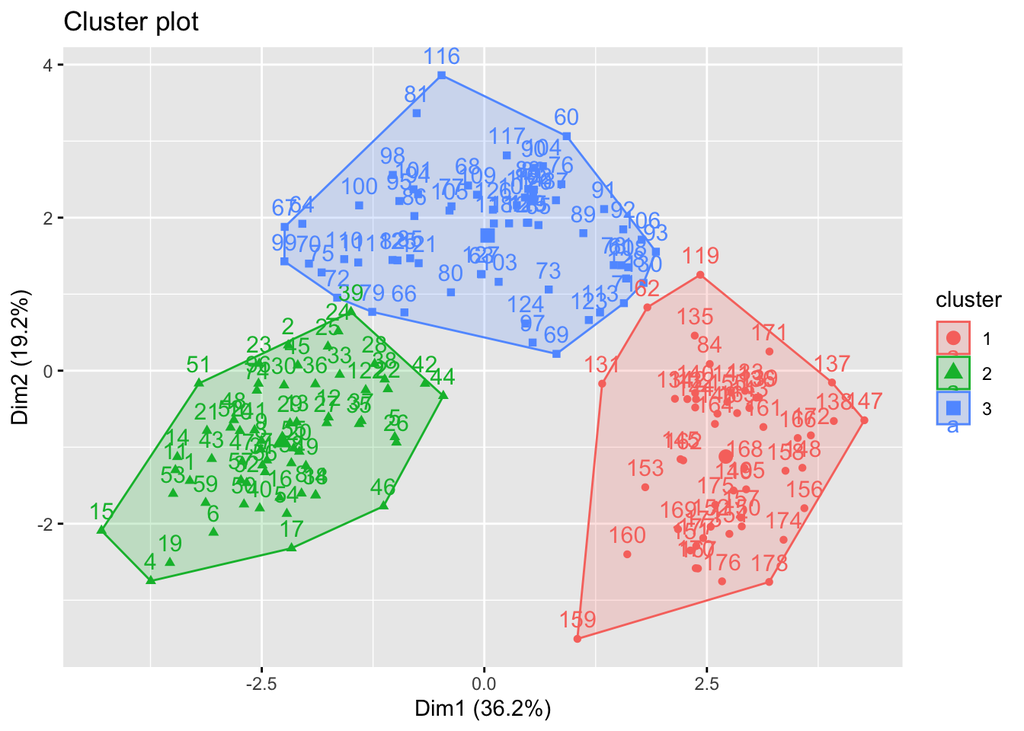

```r
# Set optimal k based on above plots
optimal_k <- 3  # Replace with your chosen k

# Perform K-Means clustering
kmeans_wine <- kmeans(wine_norm, centers = optimal_k, nstart = 25)

# Visualize clusters
fviz_cluster(kmeans_wine, data = wine_norm)
```

```r
# Analyze cluster centers and sizes
kmeans_wine$centers
```

```
##      Alcohol Malic_Acid        Ash Ash_Alcanity   Magnesium Total_Phenols
## 1  0.1644436  0.8690954  0.1863726    0.5228924 -0.07526047   -0.97657548
## 2  0.8328826 -0.3029551  0.3636801   -0.6084749  0.57596208    0.88274724
## 3 -0.9234669 -0.3929331 -0.4931257    0.1701220 -0.49032869   -0.07576891
##    Flavanoids Nonflavanoid_Phenols Proanthocyanins Color_Intensity        Hue
## 1 -1.21182921           0.72402116     -0.77751312       0.9388902 -1.1615122
## 2  0.97506900          -0.56050853      0.57865427       0.1705823  0.4726504
## 3  0.02075402          -0.03343924      0.05810161      -0.8993770  0.4605046
##        OD280    Proline
## 1 -1.2887761 -0.4059428
## 2  0.7770551  1.1220202
## 3  0.2700025 -0.7517257
```

```r
kmeans_wine$size
```

```
## [1] 51 62 65
```

*Intepretation of K-Means Clustering Results*

*Significance of Clusters*

Each cluster provides a useful segmentation of wines based on chemical composition, which is essential for identifying potential market segments

Cluster 2 targets consumers who enjoy bold and strong wines, possibly catering to premium segments or those preferring wines with a high-alcohol profile.

Cluster 3 is likely aligned with a segment that favors lighter, accessible wines suitable for casual consumption.

*Q2 DBSCAN Clustering*

Q2-A) Differences Between DBSCAN and K-Means

DBSCAN can detect noise and form clusters of arbitrary shapes, while K-Means clusters are spherical and don’t handle outliers well. Therefore, DBSCAN is effective for datasets with irregular clusters and noise.

Q2-B) Applying DBSCAN

```r
install.packages("dbscan")
install.packages("fpc")
library(dbscan)
library(fpc)
```

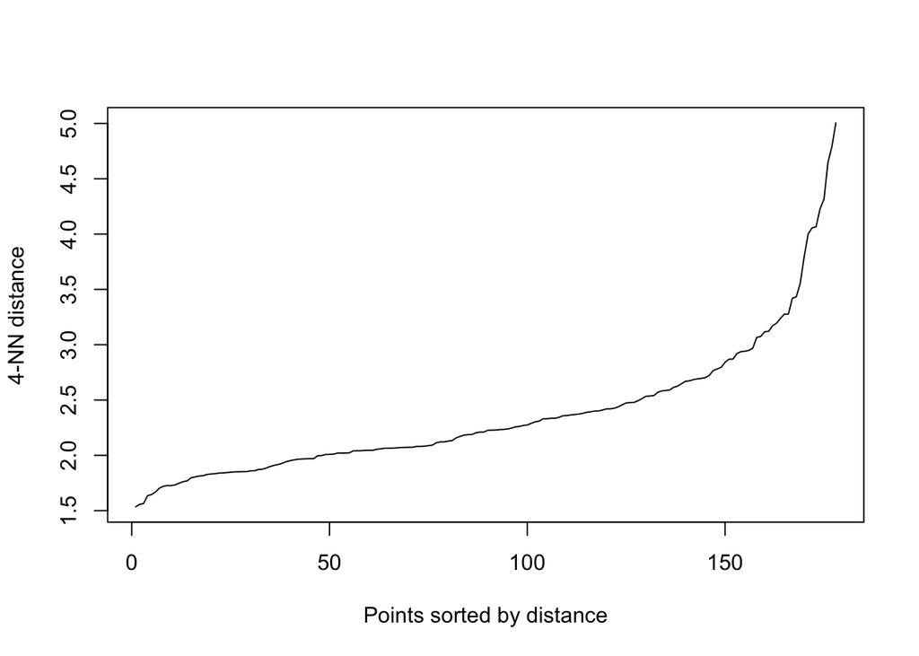

```r
# Generate the k-NN distance plot
dbscan::kNNdistplot(wine_norm, k = 4)

# Manually inspect the plot and determine the epsilon value
chosen_epsilon <- 0.5  # Replace 0.5 with the observed value from the elbow

# Add a horizontal line at the chosen epsilon value
abline(h = chosen_epsilon, col = "red")
```

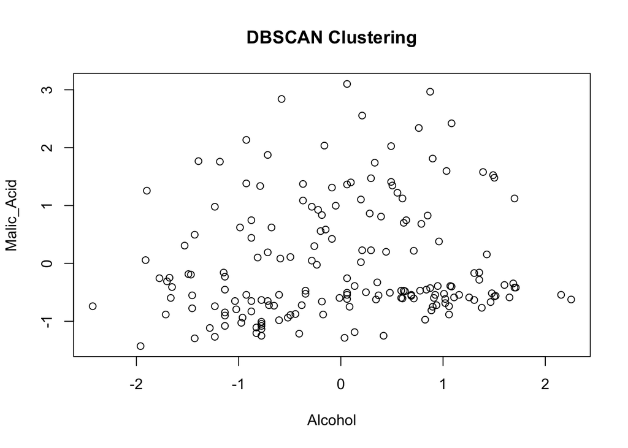

```r
# Set parameters for DBSCAN
chosen_epsilon <- 0.5  # Adjust based on kNN plot
minPts <- 5  # Example minPts value, adjust as necessary

# Apply DBSCAN
dbscan_wine <- fpc::dbscan(wine_norm, eps = chosen_epsilon, MinPts = minPts)

# Visualize DBSCAN clusters
plot(dbscan_wine, wine_norm, main = "DBSCAN Clustering")
```

*Parameter Influence*

Also, With a value of 5, MinPts defines the minimum density needed for a point to be considered a core point. Higher MinPts can make clusters tighter but may miss some lower-density regions. Lower values could cause more noise or fragmentation.

*3. Comparison of K-Means and DBSCAN*

Q3) Pros and Cons of K-Means and DBSCAN

1. Cluster Shape and Structure

K-Means Works well with spherical clusters and homogeneous data. However, it does not handle clusters with complex or irregular shapes effectively.In otherway, DBSCAN Can detect clusters of arbitrary shapes, making it more flexible in handling data with irregular clusters and varying densities, as might be observed in wine chemical data.

2. Handling of Noise and Outliers

In K-Means, every data point is assigned to a cluster, making it sensitive to outliers, as outliers can significantly skew centroids and, hence, cluster boundaries. However, DBSCAN identifies noise points and isolates them, preventing outliers from affecting the overall cluster formation. This is beneficial for datasets with variability or unique samples.

3. Sensitivity to Parameters

Under K-Means, the choice of𝑘significantly impacts results, and improper𝑘selection can lead to poor clustering. Additionally, K-Means is sensitive to initial centroids, potentially resulting in different clusters with each run. In DBSCAN, it requires careful tuning ofϵ and MinPts. Inappropriate values can result in too many points classified as noise or, conversely, the merging of distinct clusters. However, once tuned, DBSCAN is more stable and does not vary with multiple runs.

4. Application to the Wine Dataset

K-Means might work well for identifying broad types or categories of wines based on typical profiles but could misrepresent clusters in cases where wines have unique chemical profiles. DBSCAN allows for a more nuanced understanding, capturing the natural density-based grouping of wines and recognizing unique wine types or samples as noise points. This can reveal smaller or non-spherical clusters that may be meaningful in the context of wine chemistry.